# **PREDICTIVE MODELING FOR CREDIT SCORING**

### Final Project Data Scientist at ID/X Partners

**Author:** Anisa Nurhajiza

# **Business Understanding**

**Background Overview**

Multifinance companies face significant challenges in accurately assessing and managing credit risk, which is crucial for making informed business decisions and minimizing potential losses. Traditional methods often fail to capture the complexity of modern financial data, leading to suboptimal risk assessments and higher default rates.

**Objective**

Develop a robust machine learning model capable of predicting credit risk with high accuracy, thereby improving the decision-making process for loan approvals and reducing the incidence of default. The model should be interpretable to meet regulatory requirements and provide actionable insights.

**Data**

The dataset collected from 2007 to 2014 consists of various attributes that are crucial for assessing credit risk.

**Methods**

To build an effective credit risk prediction model, the following machine learning algorithms will be employed:

- Logistic Regression: A baseline model that provides interpretability and insight into feature importance.
- Decision Tree: A simple model that offers interpretability and can handle non-linear relationships.

# **Import Data and Check Dimension Data**

```python
from google.colab import drive
drive.mount('/content/drive')
```

```python
import pandas as pd

# Load the dataset
df = pd.read_csv("/content/drive/My Drive/Rakamin Academy/IDX/loan_data_2007_2014.csv")
print('This dataset has %d rows dan %d columns.\n' % df.shape)
df.head()
```

```
This dataset has 466285 rows dan 75 columns.
```

|  | Unnamed: 0 | id | member_id | loan_amnt | funded_amnt | funded_amnt_inv | term | int_rate | installment | grade | ... | total_bal_il | il_util | open_rv_12m | open_rv_24m | max_bal_bc | all_util | total_rev_hi_lim | inq_fi | total_cu_tl | inq_last_12m |
| --- | --- | --- | --- | --- | --- | --- | --- | --- | --- | --- | --- | --- | --- | --- | --- | --- | --- | --- | --- | --- | --- |
| 0 | 0 | 1077501 | 1296599 | 5000 | 5000 | 4975.0 | 36 months | 10.65 | 162.87 | B | ... | NaN | NaN | NaN | NaN | NaN | NaN | NaN | NaN | NaN | NaN |
| 1 | 1 | 1077430 | 1314167 | 2500 | 2500 | 2500.0 | 60 months | 15.27 | 59.83 | C | ... | NaN | NaN | NaN | NaN | NaN | NaN | NaN | NaN | NaN | NaN |
| 2 | 2 | 1077175 | 1313524 | 2400 | 2400 | 2400.0 | 36 months | 15.96 | 84.33 | C | ... | NaN | NaN | NaN | NaN | NaN | NaN | NaN | NaN | NaN | NaN |
| 3 | 3 | 1076863 | 1277178 | 10000 | 10000 | 10000.0 | 36 months | 13.49 | 339.31 | C | ... | NaN | NaN | NaN | NaN | NaN | NaN | NaN | NaN | NaN | NaN |
| 4 | 4 | 1075358 | 1311748 | 3000 | 3000 | 3000.0 | 60 months | 12.69 | 67.79 | B | ... | NaN | NaN | NaN | NaN | NaN | NaN | NaN | NaN | NaN | NaN |

5 rows × 75 columns

Checking whether the rows in the data represent an individual.

```python
# Check the number of unique values in the id column and the number of unique values indicating individual identities (member_id)
num_rows = df['id'].nunique()
unique_count = df['member_id'].nunique()

# Check if each row represents a single individual
if num_rows == unique_count:
    print("Each row represents a single individual.")
else:
    print("There are duplications in the data.")
```

```
Each row represents a single individual.
```

```python
# View dataset structure
df.info()
```

```
<class 'pandas.core.frame.DataFrame'>
RangeIndex: 466285 entries, 0 to 466284
Data columns (total 75 columns):
 #   Column                       Non-Null Count   Dtype
---  ------                       --------------   -----
 0   Unnamed: 0                   466285 non-null  int64
 1   id                           466285 non-null  int64
 2   member_id                    466285 non-null  int64
 3   loan_amnt                    466285 non-null  int64
 4   funded_amnt                  466285 non-null  int64
 5   funded_amnt_inv              466285 non-null  float64
 6   term                         466285 non-null  object
 7   int_rate                     466285 non-null  float64
 8   installment                  466285 non-null  float64
 9   grade                        466285 non-null  object
```

[output cut: 67 more lines]

# **Features Engineering**

```python
missing_columns = df.columns[df.isnull().all()]

# Menampilkan daftar kolom yang hanya berisi missing value
print(missing_columns)
```

```
Index(['annual_inc_joint', 'dti_joint', 'verification_status_joint',
       'open_acc_6m', 'open_il_6m', 'open_il_12m', 'open_il_24m',
       'mths_since_rcnt_il', 'total_bal_il', 'il_util', 'open_rv_12m',
       'open_rv_24m', 'max_bal_bc', 'all_util', 'inq_fi', 'total_cu_tl',
       'inq_last_12m'],
      dtype='object')
```

```python
# Defining columns will be dropped
cols_to_drop = [
    # unique id
    'Unnamed: 0',
    'id',
    'member_id',

    # free text
    'url',
    'desc',

    # others
    'zip_code',
    'mths_since_last_major_derog',
    'tot_coll_amt',
    'tot_cur_bal',
    'total_rev_hi_lim',

    # Expert judgment
    'sub_grade'
]
```

```python
# Dropping columns that contain only missing values
df = df.dropna(axis=1, how='all')
df.info()
```

```
<class 'pandas.core.frame.DataFrame'>
RangeIndex: 466285 entries, 0 to 466284
Data columns (total 58 columns):
 #   Column                       Non-Null Count   Dtype
---  ------                       --------------   -----
 0   Unnamed: 0                   466285 non-null  int64
 1   id                           466285 non-null  int64
 2   member_id                    466285 non-null  int64
 3   loan_amnt                    466285 non-null  int64
 4   funded_amnt                  466285 non-null  int64
 5   funded_amnt_inv              466285 non-null  float64
 6   term                         466285 non-null  object
 7   int_rate                     466285 non-null  float64
 8   installment                  466285 non-null  float64
 9   grade                        466285 non-null  object
```

[output cut: 50 more lines]

```python
# Dropping columns listed in cols_to_drop
df.drop(cols_to_drop, axis=1, inplace=True)

# Displaying dataset information after dropping columns
print(df.info())
```

```
<class 'pandas.core.frame.DataFrame'>
RangeIndex: 466285 entries, 0 to 466284
Data columns (total 47 columns):
 #   Column                      Non-Null Count   Dtype
---  ------                      --------------   -----
 0   loan_amnt                   466285 non-null  int64
 1   funded_amnt                 466285 non-null  int64
 2   funded_amnt_inv             466285 non-null  float64
 3   term                        466285 non-null  object
 4   int_rate                    466285 non-null  float64
 5   installment                 466285 non-null  float64
 6   grade                       466285 non-null  object
 7   emp_title                   438697 non-null  object
 8   emp_length                  445277 non-null  object
 9   home_ownership              466285 non-null  object
```

[output cut: 40 more lines]

# Defining Target Variable

```python
print(df['loan_status'].value_counts())
```

```
loan_status
Current                                                224226
Fully Paid                                             184739
Charged Off                                             42475
Late (31-120 days)                                       6900
In Grace Period                                          3146
Does not meet the credit policy. Status:Fully Paid       1988
Late (16-30 days)                                        1218
Default                                                   832
Does not meet the credit policy. Status:Charged Off       761
Name: count, dtype: int64
```

# Loan Status

1. **Current**: 224,226 loans. This indicates that the loan is active, and payments are being made on time according to the schedule. Borrowers are paying their installments without delays.
2. **Fully Paid**: 184,739 loans. These loans have been fully repaid by the borrowers. No remaining payments are due.
3. **Charged Off**: 42,475 loans. These loans are considered a loss by the lender. This typically occurs when the borrower is unable to repay the loan, and the lender decides to cease collection efforts.
4. **Late (31-120 days)**: 6,900 loans. Loans with payments overdue for 31 to 120 days.
5. **In Grace Period**: 3,146 loans. These loans are in the grace period. This is a timeframe after the payment due date during which the borrower has not yet been charged a late fee but is expected to make payment soon to avoid being marked as late.
6. **Does not meet the credit policy. Status: Fully Paid**: 1,988 loans. Loans that did not meet the credit policy but have been fully repaid.
7. **Late (16-30 days)**: 1,218 loans. These loans have payment delays ranging from 16 to 30 days. This indicates that borrowers are less than a month overdue on their installments.
8. **Default**: 832 loans. These loans are in default status, meaning the borrower has failed to repay the loan and has made no further effort to settle the debt.
9. **Does not meet the credit policy. Status: Charged Off**: 761 loans. Loans that did not meet the credit policy and are classified as a loss.

```python
import numpy as np

# List of payment statuses considered as 'bad_status'
bad_status = [
    'Charged Off',
    'Default',
    'Does not meet the credit policy. Status: Charged off',
    'Late (31-120 days)'
]

# Adding the 'bad_flag' column to indicate whether the payment status is within 'bad_status'
df['bad_flag'] = np.where(df['loan_status'].isin(bad_status), 1, 0)
```

**bad_status** contains payment statuses considered problematic or unfavorable.

```python
# Calculating the percentage distribution of values in the 'loan_status' column to obtain the proportion of values in percentage form
loan_status_percentage = df['loan_status'].value_counts(normalize=True) * 100

# Displaying the percentage distribution of values in the 'loan_status' column
print(loan_status_percentage)
```

```
loan_status
Current                                                48.087757
Fully Paid                                             39.619332
Charged Off                                             9.109236
Late (31-120 days)                                      1.479782
In Grace Period                                         0.674695
Does not meet the credit policy. Status:Fully Paid      0.426349
Late (16-30 days)                                       0.261214
Default                                                 0.178432
Does not meet the credit policy. Status:Charged Off     0.163205
Name: proportion, dtype: float64
```

```python
# Calculating the percentage distribution of values in the 'bad_flag' column
bad_flag_percentage = df['bad_flag'].value_counts(normalize=True) * 100

# Displaying the percentage distribution of values in the 'bad_flag' column
print(bad_flag_percentage)
```

```
bad_flag
0    89.232551
1    10.767449
Name: proportion, dtype: float64
```

```python
# Calculating both counts and percentages of values in the 'bad_flag' column
bad_flag_counts = df['bad_flag'].value_counts()
bad_flag_percentage = df['bad_flag'].value_counts(normalize=True) * 100

# Combining counts and percentages into a single DataFrame
bad_flag_summary = pd.DataFrame({
    'Count': bad_flag_counts,
    'Percentage': bad_flag_percentage
})

# Displaying the summary
print(bad_flag_summary)
```

```
           Count  Percentage
bad_flag
0         416078   89.232551
1          50207   10.767449
```

**0:** Approximately 89.23% of loans are categorized as non-problematic, indicating that the majority of loans in this dataset have a good payment status.

```python
# Dropping the 'loan_status' column
df.drop('loan_status', axis=1, inplace=True)
```

Removing the `loan_status` column after adding the `bad_flag` column is a common practice to simplify the dataset and focus on specific analyses. Here’s why:

- **Data Simplification**: Removing `loan_status` makes the dataset more streamlined and manageable. The `bad_flag` column provides essential information about loan status in a concise format (1 for problematic loans, 0 for non-problematic loans).
- **Redundancy**: Once the `bad_flag` column is created, most of the information in `loan_status` is already represented, making it redundant for analyses focused solely on loan performance.

# Data Cleaning

```python
df.head()
```

|  | loan_amnt | funded_amnt | funded_amnt_inv | term | int_rate | installment | grade | emp_title | emp_length | home_ownership | ... | collection_recovery_fee | last_pymnt_d | last_pymnt_amnt | next_pymnt_d | last_credit_pull_d | collections_12_mths_ex_med | policy_code | application_type | acc_now_delinq | bad_flag |
| --- | --- | --- | --- | --- | --- | --- | --- | --- | --- | --- | --- | --- | --- | --- | --- | --- | --- | --- | --- | --- | --- |
| 0 | 5000 | 5000 | 4975.0 | 36 months | 10.65 | 162.87 | B | NaN | 10+ years | RENT | ... | 0.00 | Jan-15 | 171.62 | NaN | Jan-16 | 0.0 | 1 | INDIVIDUAL | 0.0 | 0 |
| 1 | 2500 | 2500 | 2500.0 | 60 months | 15.27 | 59.83 | C | Ryder | < 1 year | RENT | ... | 1.11 | Apr-13 | 119.66 | NaN | Sep-13 | 0.0 | 1 | INDIVIDUAL | 0.0 | 1 |
| 2 | 2400 | 2400 | 2400.0 | 36 months | 15.96 | 84.33 | C | NaN | 10+ years | RENT | ... | 0.00 | Jun-14 | 649.91 | NaN | Jan-16 | 0.0 | 1 | INDIVIDUAL | 0.0 | 0 |
| 3 | 10000 | 10000 | 10000.0 | 36 months | 13.49 | 339.31 | C | AIR RESOURCES BOARD | 10+ years | RENT | ... | 0.00 | Jan-15 | 357.48 | NaN | Jan-15 | 0.0 | 1 | INDIVIDUAL | 0.0 | 0 |
| 4 | 3000 | 3000 | 3000.0 | 60 months | 12.69 | 67.79 | B | University Medical Group | 1 year | RENT | ... | 0.00 | Jan-16 | 67.79 | Feb-16 | Jan-16 | 0.0 | 1 | INDIVIDUAL | 0.0 | 0 |

5 rows × 47 columns

Column: term

```python
# Displaying unique values from the 'term' column
unique_terms = df['term'].unique()
print(unique_terms)
```

```
[' 36 months' ' 60 months']
```

```python
# Removing additional text and converting the data type to float
df['term_int'] = df['term'].str.replace(' months', '').astype(float)
df.head()
```

|  | loan_amnt | funded_amnt | funded_amnt_inv | term | int_rate | installment | grade | emp_title | emp_length | home_ownership | ... | last_pymnt_d | last_pymnt_amnt | next_pymnt_d | last_credit_pull_d | collections_12_mths_ex_med | policy_code | application_type | acc_now_delinq | bad_flag | term_int |
| --- | --- | --- | --- | --- | --- | --- | --- | --- | --- | --- | --- | --- | --- | --- | --- | --- | --- | --- | --- | --- | --- |
| 0 | 5000 | 5000 | 4975.0 | 36 months | 10.65 | 162.87 | B | NaN | 10+ years | RENT | ... | Jan-15 | 171.62 | NaN | Jan-16 | 0.0 | 1 | INDIVIDUAL | 0.0 | 0 | 36.0 |
| 1 | 2500 | 2500 | 2500.0 | 60 months | 15.27 | 59.83 | C | Ryder | < 1 year | RENT | ... | Apr-13 | 119.66 | NaN | Sep-13 | 0.0 | 1 | INDIVIDUAL | 0.0 | 1 | 60.0 |
| 2 | 2400 | 2400 | 2400.0 | 36 months | 15.96 | 84.33 | C | NaN | 10+ years | RENT | ... | Jun-14 | 649.91 | NaN | Jan-16 | 0.0 | 1 | INDIVIDUAL | 0.0 | 0 | 36.0 |
| 3 | 10000 | 10000 | 10000.0 | 36 months | 13.49 | 339.31 | C | AIR RESOURCES BOARD | 10+ years | RENT | ... | Jan-15 | 357.48 | NaN | Jan-15 | 0.0 | 1 | INDIVIDUAL | 0.0 | 0 | 36.0 |
| 4 | 3000 | 3000 | 3000.0 | 60 months | 12.69 | 67.79 | B | University Medical Group | 1 year | RENT | ... | Jan-16 | 67.79 | Feb-16 | Jan-16 | 0.0 | 1 | INDIVIDUAL | 0.0 | 0 | 60.0 |

5 rows × 48 columns

```python
# Dropping the 'term' column
df.drop('term', axis=1, inplace=True)
```

Column: emp_length

```python
# Getting unique values from the 'emp_length' column
df['emp_length'].unique()
```

```
array(['10+ years', '< 1 year', '1 year', '3 years', '8 years', '9 years',
       '4 years', '5 years', '6 years', '2 years', '7 years', nan],
      dtype=object)
```

```python
# Extracting numbers from the 'emp_length' column and converting them to float
df['emp_length_int'] = df['emp_length'].str.extract(r'(\d+)').astype(float)

# Dropping the 'emp_length' column
df.drop('emp_length', axis=1, inplace=True)

df.head()
```

|  | loan_amnt | funded_amnt | funded_amnt_inv | int_rate | installment | grade | emp_title | home_ownership | annual_inc | verification_status | ... | last_pymnt_amnt | next_pymnt_d | last_credit_pull_d | collections_12_mths_ex_med | policy_code | application_type | acc_now_delinq | bad_flag | term_int | emp_length_int |
| --- | --- | --- | --- | --- | --- | --- | --- | --- | --- | --- | --- | --- | --- | --- | --- | --- | --- | --- | --- | --- | --- |
| 0 | 5000 | 5000 | 4975.0 | 10.65 | 162.87 | B | NaN | RENT | 24000.0 | Verified | ... | 171.62 | NaN | Jan-16 | 0.0 | 1 | INDIVIDUAL | 0.0 | 0 | 36.0 | 10.0 |
| 1 | 2500 | 2500 | 2500.0 | 15.27 | 59.83 | C | Ryder | RENT | 30000.0 | Source Verified | ... | 119.66 | NaN | Sep-13 | 0.0 | 1 | INDIVIDUAL | 0.0 | 1 | 60.0 | 1.0 |
| 2 | 2400 | 2400 | 2400.0 | 15.96 | 84.33 | C | NaN | RENT | 12252.0 | Not Verified | ... | 649.91 | NaN | Jan-16 | 0.0 | 1 | INDIVIDUAL | 0.0 | 0 | 36.0 | 10.0 |
| 3 | 10000 | 10000 | 10000.0 | 13.49 | 339.31 | C | AIR RESOURCES BOARD | RENT | 49200.0 | Source Verified | ... | 357.48 | NaN | Jan-15 | 0.0 | 1 | INDIVIDUAL | 0.0 | 0 | 36.0 | 10.0 |
| 4 | 3000 | 3000 | 3000.0 | 12.69 | 67.79 | B | University Medical Group | RENT | 80000.0 | Source Verified | ... | 67.79 | Feb-16 | Jan-16 | 0.0 | 1 | INDIVIDUAL | 0.0 | 0 | 60.0 | 1.0 |

5 rows × 47 columns

Column: issue_d

```python
# Converting 'issue_d' to date format
df['issue_d_date'] = pd.to_datetime(df['issue_d'], format='%b-%y')
df.head()
```

|  | loan_amnt | funded_amnt | funded_amnt_inv | int_rate | installment | grade | emp_title | home_ownership | annual_inc | verification_status | ... | next_pymnt_d | last_credit_pull_d | collections_12_mths_ex_med | policy_code | application_type | acc_now_delinq | bad_flag | term_int | emp_length_int | issue_d_date |
| --- | --- | --- | --- | --- | --- | --- | --- | --- | --- | --- | --- | --- | --- | --- | --- | --- | --- | --- | --- | --- | --- |
| 0 | 5000 | 5000 | 4975.0 | 10.65 | 162.87 | B | NaN | RENT | 24000.0 | Verified | ... | NaN | Jan-16 | 0.0 | 1 | INDIVIDUAL | 0.0 | 0 | 36.0 | 10.0 | 2011-12-01 |
| 1 | 2500 | 2500 | 2500.0 | 15.27 | 59.83 | C | Ryder | RENT | 30000.0 | Source Verified | ... | NaN | Sep-13 | 0.0 | 1 | INDIVIDUAL | 0.0 | 1 | 60.0 | 1.0 | 2011-12-01 |
| 2 | 2400 | 2400 | 2400.0 | 15.96 | 84.33 | C | NaN | RENT | 12252.0 | Not Verified | ... | NaN | Jan-16 | 0.0 | 1 | INDIVIDUAL | 0.0 | 0 | 36.0 | 10.0 | 2011-12-01 |
| 3 | 10000 | 10000 | 10000.0 | 13.49 | 339.31 | C | AIR RESOURCES BOARD | RENT | 49200.0 | Source Verified | ... | NaN | Jan-15 | 0.0 | 1 | INDIVIDUAL | 0.0 | 0 | 36.0 | 10.0 | 2011-12-01 |
| 4 | 3000 | 3000 | 3000.0 | 12.69 | 67.79 | B | University Medical Group | RENT | 80000.0 | Source Verified | ... | Feb-16 | Jan-16 | 0.0 | 1 | INDIVIDUAL | 0.0 | 0 | 60.0 | 1.0 | 2011-12-01 |

5 rows × 48 columns

```python
# Calculating the number of months since 'issue_d' until the reference date
from dateutil.relativedelta import relativedelta

# Assuming 'issue_d_date' column exists in the DataFrame and is in datetime format
reference_date = pd.to_datetime('2017-12-01')

# Define a function to calculate months difference
def months_difference(issue_date, ref_date):
    return relativedelta(ref_date, issue_date).years * 12 + relativedelta(ref_date, issue_date).months

# Apply the function to calculate months difference
df['mths_since_issue_d'] = df['issue_d_date'].apply(lambda x: months_difference(x, reference_date))

df.head()
```

|  | loan_amnt | funded_amnt | funded_amnt_inv | int_rate | installment | grade | emp_title | home_ownership | annual_inc | verification_status | ... | last_credit_pull_d | collections_12_mths_ex_med | policy_code | application_type | acc_now_delinq | bad_flag | term_int | emp_length_int | issue_d_date | mths_since_issue_d |
| --- | --- | --- | --- | --- | --- | --- | --- | --- | --- | --- | --- | --- | --- | --- | --- | --- | --- | --- | --- | --- | --- |
| 0 | 5000 | 5000 | 4975.0 | 10.65 | 162.87 | B | NaN | RENT | 24000.0 | Verified | ... | Jan-16 | 0.0 | 1 | INDIVIDUAL | 0.0 | 0 | 36.0 | 10.0 | 2011-12-01 | 72 |
| 1 | 2500 | 2500 | 2500.0 | 15.27 | 59.83 | C | Ryder | RENT | 30000.0 | Source Verified | ... | Sep-13 | 0.0 | 1 | INDIVIDUAL | 0.0 | 1 | 60.0 | 1.0 | 2011-12-01 | 72 |
| 2 | 2400 | 2400 | 2400.0 | 15.96 | 84.33 | C | NaN | RENT | 12252.0 | Not Verified | ... | Jan-16 | 0.0 | 1 | INDIVIDUAL | 0.0 | 0 | 36.0 | 10.0 | 2011-12-01 | 72 |
| 3 | 10000 | 10000 | 10000.0 | 13.49 | 339.31 | C | AIR RESOURCES BOARD | RENT | 49200.0 | Source Verified | ... | Jan-15 | 0.0 | 1 | INDIVIDUAL | 0.0 | 0 | 36.0 | 10.0 | 2011-12-01 | 72 |
| 4 | 3000 | 3000 | 3000.0 | 12.69 | 67.79 | B | University Medical Group | RENT | 80000.0 | Source Verified | ... | Jan-16 | 0.0 | 1 | INDIVIDUAL | 0.0 | 0 | 60.0 | 1.0 | 2011-12-01 | 72 |

5 rows × 49 columns

**mths_since_issue_d**

- This column calculates the duration in months between two dates: `issue_d_date` and the reference date `2017-12-01`.
- This duration can be used for various time-based analyses, such as studying behavioral patterns based on the age of an account or event.

```python
# Descriptive statistics for the 'mths_since_issue_d' column
print(df['mths_since_issue_d'].describe())
```

```
count    466285.000000
mean         51.255187
std          14.340154
min          36.000000
25%          41.000000
50%          47.000000
75%          57.000000
max         126.000000
Name: mths_since_issue_d, dtype: float64
```

```python
# Dropping the columns 'issue_d' and 'issue_d_date'
df.drop(['issue_d', 'issue_d_date'], axis=1, inplace=True)
```

Column: earliest_cr_line

```python
print(df['earliest_cr_line'].head())
```

```
0    Jan-85
1    Apr-99
2    Nov-01
3    Feb-96
4    Jan-96
Name: earliest_cr_line, dtype: object
```

```python
# Converting 'earliest_cr_line' to date format
df['earliest_cr_line_date'] = pd.to_datetime(df['earliest_cr_line'], format='%b-%y')
print(df['earliest_cr_line_date'].head())
```

```
0   1985-01-01
1   1999-04-01
2   2001-11-01
3   1996-02-01
4   1996-01-01
Name: earliest_cr_line_date, dtype: datetime64[ns]
```

```python
import pandas as pd
from dateutil.relativedelta import relativedelta

# Reference date
reference_date = pd.to_datetime('2017-12-01')

# Function to calculate months difference
def months_difference(issue_date, ref_date):
    if pd.isna(issue_date):  # Handle missing dates
        return None
    return relativedelta(ref_date, issue_date).years * 12 + relativedelta(ref_date, issue_date).months

# Ensure 'earliest_cr_line_date' is in datetime format
df['earliest_cr_line_date'] = pd.to_datetime(df['earliest_cr_line_date'], errors='coerce')

# Apply the function to calculate months difference
df['mths_since_earliest_cr_line'] = df['earliest_cr_line_date'].apply(lambda x: months_difference(x, reference_date))

print(df['mths_since_earliest_cr_line'].head())
```

```
0    395.0
1    224.0
2    193.0
3    262.0
4    263.0
Name: mths_since_earliest_cr_line, dtype: float64
```

**mths_since_earliest_cr_line**

A column that represents the number of months elapsed from the date in `earliest_cr_line_date` to the reference date `2017-12-01`. These values indicate the duration in months from that date to the reference date.

```python
# Descriptive statistics for the 'mths_since_earliest_cr_line' column
print(df['mths_since_earliest_cr_line'].describe())
```

```
count    466256.000000
mean        239.482430
std          93.974829
min        -612.000000
25%         183.000000
50%         225.000000
75%         285.000000
max         587.000000
Name: mths_since_earliest_cr_line, dtype: float64
```

```python
# Displaying rows with 'mths_since_earliest_cr_line' values less than 0
print(df[df['mths_since_earliest_cr_line'] < 0][['earliest_cr_line', 'earliest_cr_line_date', 'mths_since_earliest_cr_line']].head())
```

```
     earliest_cr_line earliest_cr_line_date  mths_since_earliest_cr_line
1580           Sep-62            2062-09-01                       -537.0
1770           Sep-68            2068-09-01                       -609.0
2799           Sep-64            2064-09-01                       -561.0
3282           Sep-67            2067-09-01                       -597.0
3359           Feb-65            2065-02-01                       -566.0
```

The negative values occurred because the Python function misinterpreted the year `62` as `2062` instead of `1962`.

To address this, further preprocessing can be done to correct the year `2062` to `1962`. However, in this case, negative values are simply replaced with the maximum value of the feature, as they represent older data (from the 1900s), making this adjustment reasonable.

```python
# Replacing values in 'mths_since_earliest_cr_line' less than 0 with the maximum value
df.loc[df['mths_since_earliest_cr_line'] < 0, 'mths_since_earliest_cr_line'] = df['mths_since_earliest_cr_line'].max()
```

```python
# Dropping the columns 'earliest_cr_line' and 'earliest_cr_line_date'
df.drop(['earliest_cr_line', 'earliest_cr_line_date'], axis=1, inplace=True)
```

Column: last_pymnt_d

```python
# Converting 'last_paymnt_d' to date format
df['last_pymnt_d_date'] = pd.to_datetime(df['last_pymnt_d'], format='%b-%y')
```

```python
# Calculating the number of months since 'last_payment_d' until the reference date
import pandas as pd
from dateutil.relativedelta import relativedelta

# Reference date
reference_date = pd.to_datetime('2017-12-01')

# Function to calculate months difference
def months_difference(issue_date, ref_date):
    if pd.isna(issue_date):  # Handle missing dates
        return None
    return relativedelta(ref_date, issue_date).years * 12 + relativedelta(ref_date, issue_date).months

# Ensure 'last_pymnt_d_date' is in datetime format
df['last_pymnt_d_date'] = pd.to_datetime(df['last_pymnt_d_date'], errors='coerce')

# Apply the function to calculate months difference
df['mths_since_last_pymnt_d'] = df['last_pymnt_d_date'].apply(lambda x: months_difference(x, reference_date))

print(df['mths_since_last_pymnt_d'].head())
```

```
0    35.0
1    56.0
2    42.0
3    35.0
4    23.0
Name: mths_since_last_pymnt_d, dtype: float64
```

```python
# Descriptive statistics for the 'mths_since_last_pymnt_d' column
print(df['mths_since_last_pymnt_d'].describe())
```

```
count    465909.000000
mean         31.294369
std          12.809898
min          23.000000
25%          23.000000
50%          24.000000
75%          35.000000
max         120.000000
Name: mths_since_last_pymnt_d, dtype: float64
```

```python
# Dropping the columns 'last_pymnt_d' and 'last_pymnt_d_date'
df.drop(['last_pymnt_d', 'last_pymnt_d_date'], axis=1, inplace=True)
```

Column: next_pymnt_d

```python
# Converting 'next_pymnt_d' to date format
df['next_pymnt_d_date'] = pd.to_datetime(df['next_pymnt_d'], format='%b-%y')
```

```python
# Calculating the number of months since 'next_pymnt_d' until the reference date
import pandas as pd
from dateutil.relativedelta import relativedelta

# Reference date
reference_date = pd.to_datetime('2017-12-01')

# Function to calculate months difference
def months_difference(issue_date, ref_date):
    if pd.isna(issue_date):  # Handle missing dates
        return None
    return relativedelta(ref_date, issue_date).years * 12 + relativedelta(ref_date, issue_date).months

# Ensure 'next_pymnt_d_date' is in datetime format
df['next_pymnt_d_date'] = pd.to_datetime(df['next_pymnt_d_date'], errors='coerce')

# Apply the function to calculate months difference
df['mths_since_next_pymnt_d'] = df['next_pymnt_d_date'].apply(lambda x: months_difference(x, reference_date))

print(df['mths_since_next_pymnt_d'].head())
```

```
0     NaN
1     NaN
2     NaN
3     NaN
4    22.0
Name: mths_since_next_pymnt_d, dtype: float64
```

```python
# Descriptive statistics for the 'mths_since_next_pymnt_d' column
print(df['mths_since_next_pymnt_d'].describe())
```

```
count    239071.000000
mean         22.738136
std           6.082298
min          21.000000
25%          22.000000
50%          22.000000
75%          22.000000
max         120.000000
Name: mths_since_next_pymnt_d, dtype: float64
```

```python
# Dropping the columns 'next_pymnt_d' and 'next_pymnt_d_date'
df.drop(['next_pymnt_d', 'next_pymnt_d_date'], axis=1, inplace=True)
```

Column: last_credit_pull_d

```python
# Converting 'last_credit_pull_d' to date format
df['last_credit_pull_d_date'] = pd.to_datetime(df['last_credit_pull_d'], format='%b-%y')
```

```python
# Calculating the number of months since 'last_credit_pull_d' until the reference date
import pandas as pd
from dateutil.relativedelta import relativedelta

# Reference date
reference_date = pd.to_datetime('2017-12-01')

# Function to calculate months difference
def months_difference(issue_date, ref_date):
    if pd.isna(issue_date):  # Handle missing dates
        return None
    return relativedelta(ref_date, issue_date).years * 12 + relativedelta(ref_date, issue_date).months

# Ensure 'last_credit_pull_d_date' is in datetime format
df['last_credit_pull_d_date'] = pd.to_datetime(df['last_credit_pull_d_date'], errors='coerce')

# Apply the function to calculate months difference
df['mths_since_last_credit_pull_d'] = df['last_credit_pull_d_date'].apply(lambda x: months_difference(x, reference_date))

print(df['mths_since_last_credit_pull_d'].head())
```

```
0    23.0
1    51.0
2    23.0
3    35.0
4    23.0
Name: mths_since_last_credit_pull_d, dtype: float64
```

```python
# Descriptive statistics for the 'mths_since_last_credit_pull_d' column
print(df['mths_since_last_credit_pull_d'].describe())
```

```
count    466243.000000
mean         27.045588
std           9.636423
min          23.000000
25%          23.000000
50%          23.000000
75%          25.000000
max         127.000000
Name: mths_since_last_credit_pull_d, dtype: float64
```

```python
# Dropping the columns 'last_credit_pull_d' and 'last_credit_pull_d_date'
df.drop(['last_credit_pull_d', 'last_credit_pull_d_date'], axis=1, inplace=True)
```

```python
df.head()
```

|  | loan_amnt | funded_amnt | funded_amnt_inv | int_rate | installment | grade | emp_title | home_ownership | annual_inc | verification_status | ... | application_type | acc_now_delinq | bad_flag | term_int | emp_length_int | mths_since_issue_d | mths_since_earliest_cr_line | mths_since_last_pymnt_d | mths_since_next_pymnt_d | mths_since_last_credit_pull_d |
| --- | --- | --- | --- | --- | --- | --- | --- | --- | --- | --- | --- | --- | --- | --- | --- | --- | --- | --- | --- | --- | --- |
| 0 | 5000 | 5000 | 4975.0 | 10.65 | 162.87 | B | NaN | RENT | 24000.0 | Verified | ... | INDIVIDUAL | 0.0 | 0 | 36.0 | 10.0 | 72 | 395.0 | 35.0 | NaN | 23.0 |
| 1 | 2500 | 2500 | 2500.0 | 15.27 | 59.83 | C | Ryder | RENT | 30000.0 | Source Verified | ... | INDIVIDUAL | 0.0 | 1 | 60.0 | 1.0 | 72 | 224.0 | 56.0 | NaN | 51.0 |
| 2 | 2400 | 2400 | 2400.0 | 15.96 | 84.33 | C | NaN | RENT | 12252.0 | Not Verified | ... | INDIVIDUAL | 0.0 | 0 | 36.0 | 10.0 | 72 | 193.0 | 42.0 | NaN | 23.0 |
| 3 | 10000 | 10000 | 10000.0 | 13.49 | 339.31 | C | AIR RESOURCES BOARD | RENT | 49200.0 | Source Verified | ... | INDIVIDUAL | 0.0 | 0 | 36.0 | 10.0 | 72 | 262.0 | 35.0 | NaN | 35.0 |
| 4 | 3000 | 3000 | 3000.0 | 12.69 | 67.79 | B | University Medical Group | RENT | 80000.0 | Source Verified | ... | INDIVIDUAL | 0.0 | 0 | 60.0 | 1.0 | 72 | 263.0 | 23.0 | 22.0 | 23.0 |

5 rows × 47 columns

# **Exploratory Data Analysis**

# Check Correlation

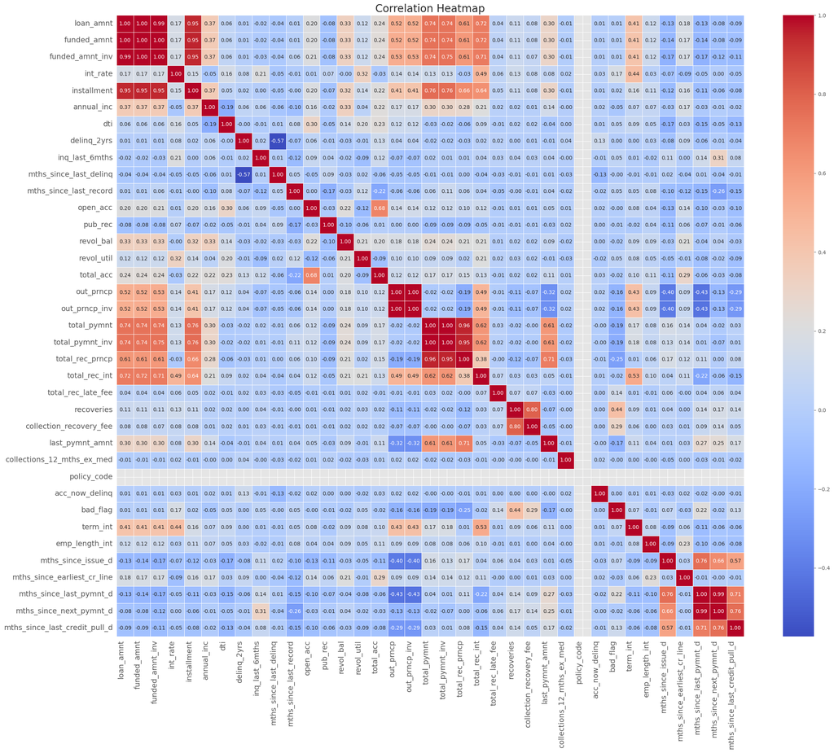

```python
import seaborn as sns
import matplotlib.pyplot as plt

numeric_df = df.select_dtypes(include=['int64', 'float64'])

# Hitung korelasi antar kolom numerik
correlation_matrix = numeric_df.corr()

# Buat heatmap korelasi
plt.figure(figsize=(24, 20))
sns.heatmap(correlation_matrix, annot=True, cmap='coolwarm', fmt=".2f", annot_kws={"size": 10}, linewidths=0.5)
plt.title('Correlation Heatmap', fontsize=20)
plt.xticks(fontsize=14, rotation=90, ha='right')
plt.yticks(fontsize=14, rotation=0)
plt.tight_layout()
plt.show()
```

# Check Cardinality Data

Categorical Data

```python
# Dropping features with high correlation
df.drop(['funded_amnt', 'funded_amnt_inv', 'installment', 'out_prncp_inv', 'total_rec_prncp',
         'total_pymnt', 'total_pymnt_inv', 'total_rec_int', 'collection_recovery_fee',
         'last_pymnt_amnt', 'mths_since_last_pymnt_d', 'mths_since_next_pymnt_d',
         'mths_since_last_credit_pull_d'], axis=1, inplace=True)
```

```python
# The number of unique values for features with object data type
print(df.select_dtypes(include='object').nunique())
```

```
grade                       7
emp_title              205475
home_ownership              6
verification_status         3
pymnt_plan                  2
purpose                    14
title                   63098
addr_state                 50
initial_list_status         2
application_type            1
dtype: int64
```

```python
# Dropping 3 features
df.drop(['emp_title', 'title', 'application_type'], axis=1, inplace=True)
df.head()
```

|  | loan_amnt | int_rate | grade | home_ownership | annual_inc | verification_status | pymnt_plan | purpose | addr_state | dti | ... | total_rec_late_fee | recoveries | collections_12_mths_ex_med | policy_code | acc_now_delinq | bad_flag | term_int | emp_length_int | mths_since_issue_d | mths_since_earliest_cr_line |
| --- | --- | --- | --- | --- | --- | --- | --- | --- | --- | --- | --- | --- | --- | --- | --- | --- | --- | --- | --- | --- | --- |
| 0 | 5000 | 10.65 | B | RENT | 24000.0 | Verified | n | credit_card | AZ | 27.65 | ... | 0.00 | 0.00 | 0.0 | 1 | 0.0 | 0 | 36.0 | 10.0 | 72 | 395.0 |
| 1 | 2500 | 15.27 | C | RENT | 30000.0 | Source Verified | n | car | GA | 1.00 | ... | 0.00 | 117.08 | 0.0 | 1 | 0.0 | 1 | 60.0 | 1.0 | 72 | 224.0 |
| 2 | 2400 | 15.96 | C | RENT | 12252.0 | Not Verified | n | small_business | IL | 8.72 | ... | 0.00 | 0.00 | 0.0 | 1 | 0.0 | 0 | 36.0 | 10.0 | 72 | 193.0 |
| 3 | 10000 | 13.49 | C | RENT | 49200.0 | Source Verified | n | other | CA | 20.00 | ... | 16.97 | 0.00 | 0.0 | 1 | 0.0 | 0 | 36.0 | 10.0 | 72 | 262.0 |
| 4 | 3000 | 12.69 | B | RENT | 80000.0 | Source Verified | n | other | OR | 17.94 | ... | 0.00 | 0.00 | 0.0 | 1 | 0.0 | 0 | 60.0 | 1.0 | 72 | 263.0 |

5 rows × 31 columns

Numerical Data

```python
# The number of unique values for features with non-object data type
print(df.select_dtypes(exclude='object').nunique())
```

```
loan_amnt                        1352
int_rate                          506
annual_inc                      31901
dti                              3997
delinq_2yrs                        24
inq_last_6mths                     28
mths_since_last_delinq            145
mths_since_last_record            123
open_acc                           62
pub_rec                            26
revol_bal                       58142
revol_util                       1269
total_acc                         112
out_prncp                      135665
total_rec_late_fee               5808
recoveries                      22773
collections_12_mths_ex_med          9
policy_code                         1
acc_now_delinq                      6
bad_flag                            2
term_int                            2
emp_length_int                     10
mths_since_issue_d                 91
mths_since_earliest_cr_line       515
dtype: int64
```

```python
# Dropping the 'policy_code' feature
df.drop(['policy_code'], axis=1, inplace=True)
```

```python
# Loop through each feature with object data type
for col in df.select_dtypes(include=['object']).columns.tolist():
    # Display the distribution of unique values for each feature
    print("Distribution of unique values for feature", col)
    print(df[col].value_counts(normalize=True) * 100)
    print('\n')
```

```
Distribution of unique values for feature grade
grade
B    29.365946
C    26.870476
D    16.489486
A    16.056060
E     7.668486
F     2.837106
G     0.712440
Name: proportion, dtype: float64


Distribution of unique values for feature home_ownership
home_ownership
MORTGAGE    50.586015
RENT        40.420129
OWN          8.943886
OTHER        0.039032
NONE         0.010723
ANY          0.000214
Name: proportion, dtype: float64


Distribution of unique values for feature verification_status
verification_status
Verified           36.041262
Source Verified    32.167666
Not Verified       31.791072
Name: proportion, dtype: float64


Distribution of unique values for feature pymnt_plan
pymnt_plan
n    99.99807
y     0.00193
Name: proportion, dtype: float64


Distribution of unique values for feature purpose
purpose
```

[output cut: 62 more lines]

```
WY     0.241912
SD     0.210172
VT     0.194087
IA     0.003002
NE     0.003002
ID     0.002574
ME     0.000858
Name: proportion, dtype: float64


Distribution of unique values for feature initial_list_status
initial_list_status
f    64.982789
w    35.017211
Name: proportion, dtype: float64
```

Pada tahap ini, fitur yang didominasi oleh satu nilai secara signifikan akan dihapus dari dataset. Hal ini dilakukan untuk menghilangkan fitur yang tidak memberikan variasi atau informasi tambahan dalam proses pemodelan

```python
# Dropping the 'pymnt_plan' feature from the dataset
df.drop('pymnt_plan', axis=1, inplace=True)
df.info()
```

```
<class 'pandas.core.frame.DataFrame'>
RangeIndex: 466285 entries, 0 to 466284
Data columns (total 29 columns):
 #   Column                       Non-Null Count   Dtype
---  ------                       --------------   -----
 0   loan_amnt                    466285 non-null  int64
 1   int_rate                     466285 non-null  float64
 2   grade                        466285 non-null  object
 3   home_ownership               466285 non-null  object
 4   annual_inc                   466281 non-null  float64
 5   verification_status          466285 non-null  object
 6   purpose                      466285 non-null  object
 7   addr_state                   466285 non-null  object
 8   dti                          466285 non-null  float64
 9   delinq_2yrs                  466256 non-null  float64
```

[output cut: 21 more lines]

# Univariate Analysis

```
Index(['grade', 'home_ownership', 'verification_status', 'purpose',
       'addr_state', 'initial_list_status'],
      dtype='object')
```

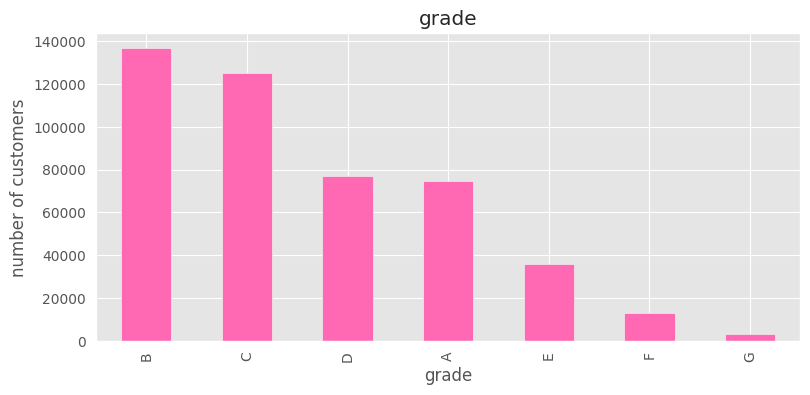

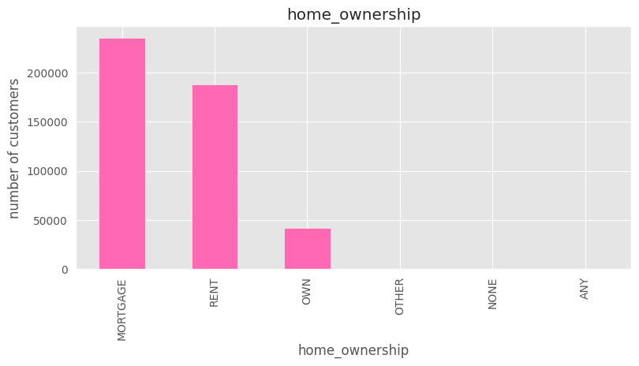

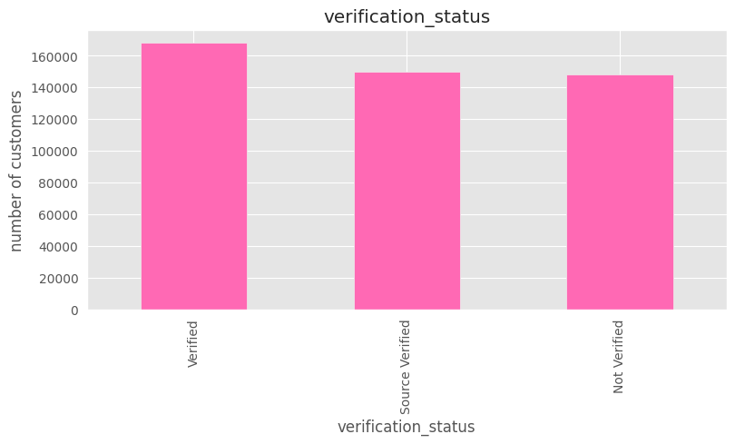

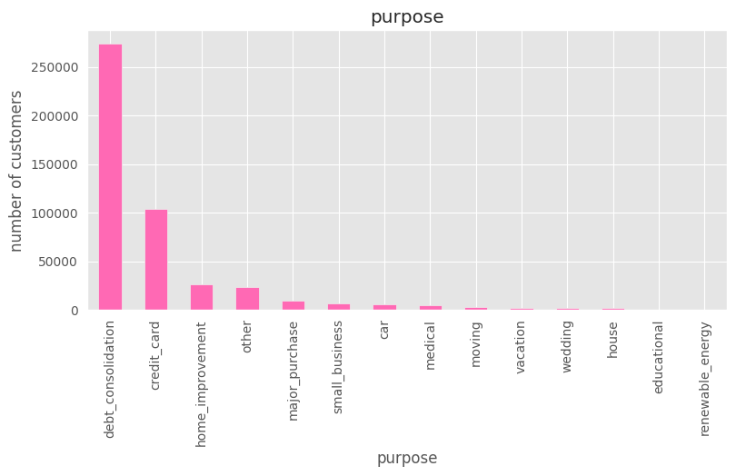

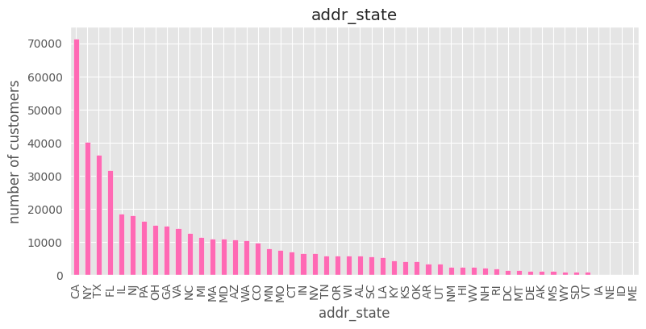

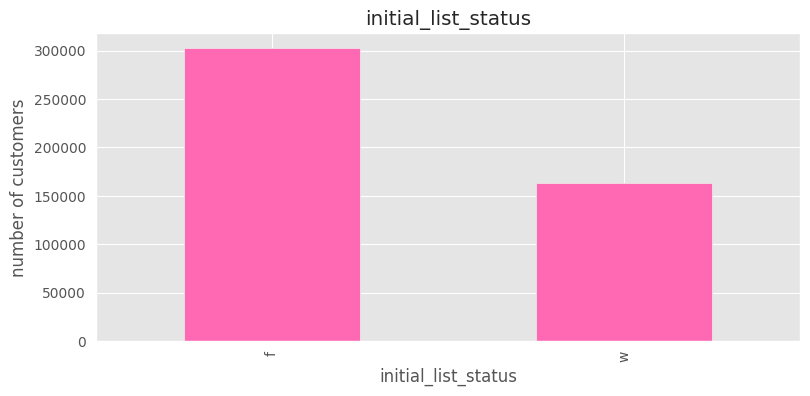

```python
# identifying the categorical variables
cat_var = df.select_dtypes(include=["object"]).columns
print(cat_var)

# plotting bar chart for each categorical variable
plt.style.use("ggplot")

for column in cat_var:
    plt.figure(figsize=(20, 4))
    plt.subplot(121)
    df[column].value_counts().plot(kind="bar", color="HotPink")
    plt.xlabel(column)
    plt.ylabel("number of customers")
    plt.title(column)
```

Numerical Data

```python
# Identifying the numerical variables
num_var = df.select_dtypes(include = np.number)
num_var.head()
```

|  | loan_amnt | int_rate | annual_inc | dti | delinq_2yrs | inq_last_6mths | mths_since_last_delinq | mths_since_last_record | open_acc | pub_rec | ... | out_prncp | total_rec_late_fee | recoveries | collections_12_mths_ex_med | acc_now_delinq | bad_flag | term_int | emp_length_int | mths_since_issue_d | mths_since_earliest_cr_line |
| --- | --- | --- | --- | --- | --- | --- | --- | --- | --- | --- | --- | --- | --- | --- | --- | --- | --- | --- | --- | --- | --- |
| 0 | 5000 | 10.65 | 24000.0 | 27.65 | 0.0 | 1.0 | NaN | NaN | 3.0 | 0.0 | ... | 0.0 | 0.00 | 0.00 | 0.0 | 0.0 | 0 | 36.0 | 10.0 | 72 | 395.0 |
| 1 | 2500 | 15.27 | 30000.0 | 1.00 | 0.0 | 5.0 | NaN | NaN | 3.0 | 0.0 | ... | 0.0 | 0.00 | 117.08 | 0.0 | 0.0 | 1 | 60.0 | 1.0 | 72 | 224.0 |
| 2 | 2400 | 15.96 | 12252.0 | 8.72 | 0.0 | 2.0 | NaN | NaN | 2.0 | 0.0 | ... | 0.0 | 0.00 | 0.00 | 0.0 | 0.0 | 0 | 36.0 | 10.0 | 72 | 193.0 |
| 3 | 10000 | 13.49 | 49200.0 | 20.00 | 0.0 | 1.0 | 35.0 | NaN | 10.0 | 0.0 | ... | 0.0 | 16.97 | 0.00 | 0.0 | 0.0 | 0 | 36.0 | 10.0 | 72 | 262.0 |
| 4 | 3000 | 12.69 | 80000.0 | 17.94 | 0.0 | 0.0 | 38.0 | NaN | 15.0 | 0.0 | ... | 766.9 | 0.00 | 0.00 | 0.0 | 0.0 | 0 | 60.0 | 1.0 | 72 | 263.0 |

5 rows × 23 columns

```
Summary statistics of loan_amnt
Mean:  14317.28
Standard deviation:  8286.51
Median:  12000.00
Mode:  10000
```

```
Summary statistics of int_rate
Mean:  13.83
Standard deviation:  4.36
Median:  13.66
Mode:  12.99
```

```
Summary statistics of annual_inc
Mean:  73277.38
Standard deviation:  54963.57
Median:  63000.00
Mode:  60000.0
```

```
Summary statistics of dti
Mean:  17.22
Standard deviation:  7.85
Median:  16.87
Mode:  14.4
```

```
Summary statistics of delinq_2yrs
Mean:  0.28
Standard deviation:  0.80
Median:  0.00
Mode:  0.0
```

```
Summary statistics of inq_last_6mths
Mean:  0.80
Standard deviation:  1.09
Median:  0.00
Mode:  0.0
```

```
Summary statistics of mths_since_last_delinq
Mean:  34.10
Standard deviation:  21.78
Median:  31.00
Mode:  9.0
```

```
Summary statistics of mths_since_last_record
Mean:  74.31
Standard deviation:  30.36
Median:  76.00
Mode:  0.0
```

```
Summary statistics of open_acc
Mean:  11.19
Standard deviation:  4.99
Median:  10.00
Mode:  9.0
```

```
Summary statistics of pub_rec
Mean:  0.16
Standard deviation:  0.51
Median:  0.00
Mode:  0.0
```

```
Summary statistics of revol_bal
Mean:  16230.20
Standard deviation:  20676.25
Median:  11764.00
Mode:  0
```

```
Summary statistics of revol_util
Mean:  56.18
Standard deviation:  23.73
Median:  57.60
Mode:  0.0
```

```
Summary statistics of total_acc
Mean:  25.06
Standard deviation:  11.60
Median:  23.00
Mode:  21.0
```

```
Summary statistics of out_prncp
Mean:  4410.06
Standard deviation:  6355.08
Median:  441.47
Mode:  0.0
```

```
Summary statistics of total_rec_late_fee
Mean:  0.65
Standard deviation:  5.27
Median:  0.00
Mode:  0.0
```

```
Summary statistics of recoveries
Mean:  85.34
Standard deviation:  552.22
Median:  0.00
Mode:  0.0
```

```
Summary statistics of collections_12_mths_ex_med
Mean:  0.01
Standard deviation:  0.11
Median:  0.00
Mode:  0.0
```

```
Summary statistics of acc_now_delinq
Mean:  0.00
Standard deviation:  0.07
Median:  0.00
Mode:  0.0
```

```
Summary statistics of bad_flag
Mean:  0.11
Standard deviation:  0.31
Median:  0.00
Mode:  0
```

```
Summary statistics of term_int
Mean:  42.61
Standard deviation:  10.72
Median:  36.00
Mode:  36.0
```

```
Summary statistics of emp_length_int
Mean:  6.07
Standard deviation:  3.50
Median:  6.00
Mode:  10.0
```

```
Summary statistics of mths_since_issue_d
Mean:  51.26
Standard deviation:  14.34
Median:  47.00
Mode:  38
```

```
Summary statistics of mths_since_earliest_cr_line
Mean:  242.39
Standard deviation:  86.46
Median:  226.00
Mode:  206.0
```

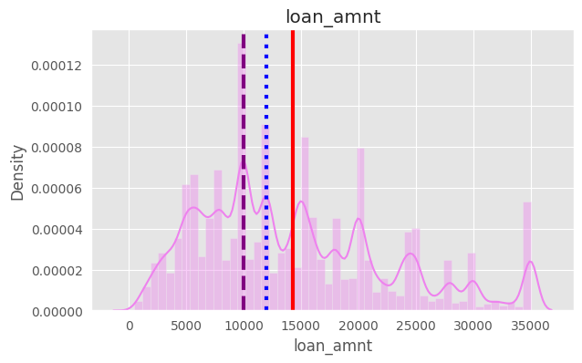

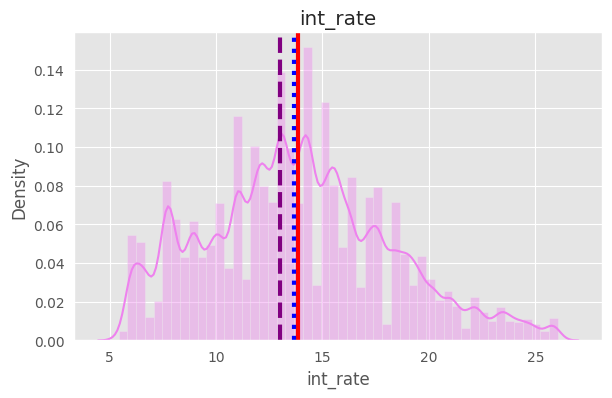

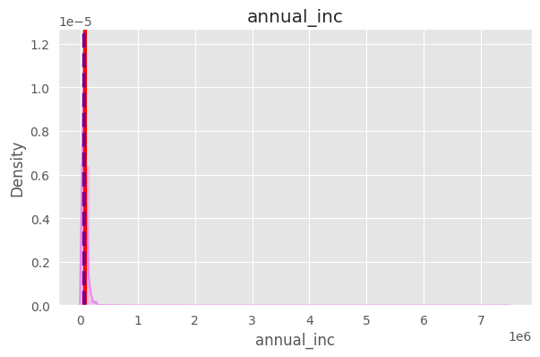

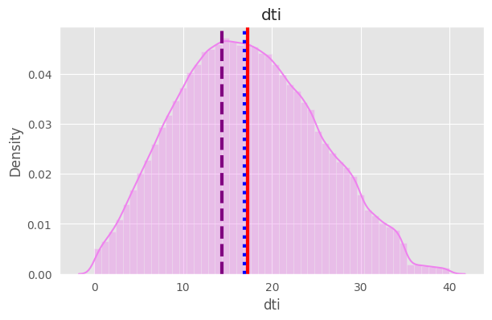

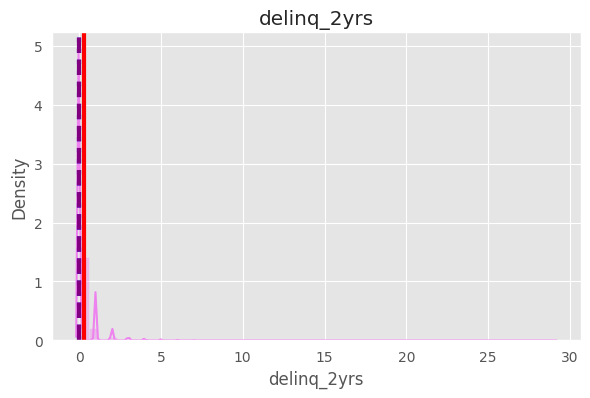

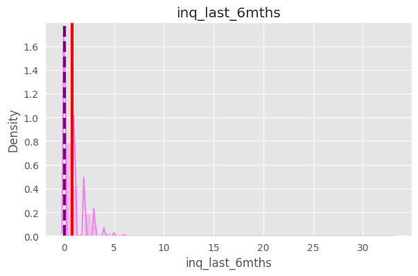

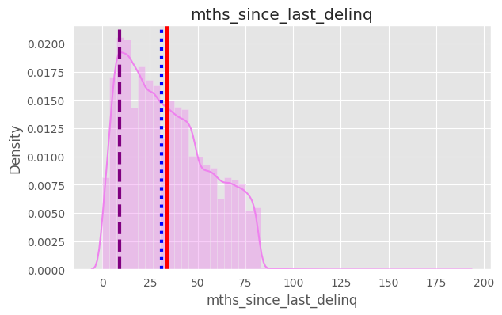

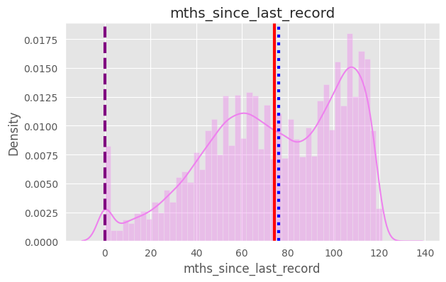

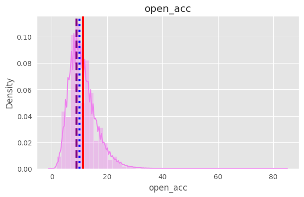

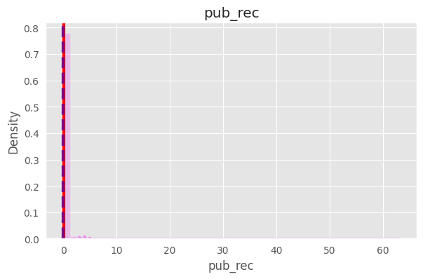

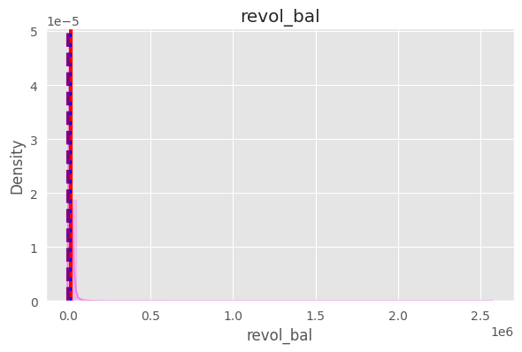

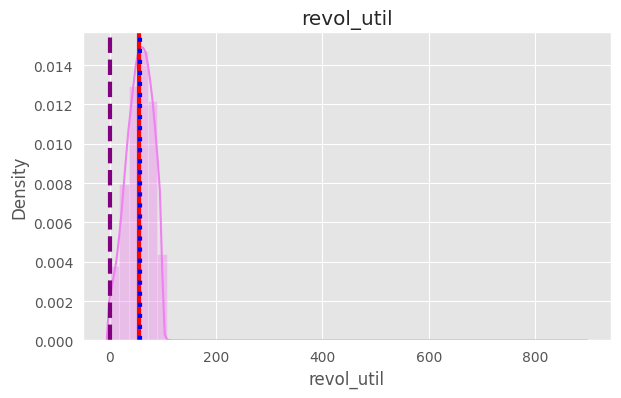

[11 more figures not shown]

```python
# Plotting histogram for each numeric variable
plt.style.use("ggplot")

# Filtering columns with dtype other than 'object'
for column in df.select_dtypes(exclude='object').columns.tolist():
    # Calculating descriptive statistics
    average = df[column].mean()
    median = df[column].median()
    mode = df[column].mode().iloc[0] # Taking the first mode (as there can be multiple modes)
    std = df[column].std()

    # Creating subplot for histogram
    plt.figure(figsize=(15, 4))

    plt.subplot(121)
    sns.distplot(df[column], kde=True, color='Violet')
    plt.axvline(average, color='r', linestyle='solid', linewidth=3, label='Mean')
    plt.axvline(median, color='b', linestyle='dotted', linewidth=3, label='Median')
    plt.axvline(mode, color='purple', linestyle='dashed', linewidth=3, label='Mode')
    plt.title(column)

    # Displaying summary statistics
    print('Summary statistics of {column}'.format(column=column))
    print('Mean: ', "%.2f" % average)
    print('Standard deviation: ', "%.2f" % std)
    print('Median: ', "%.2f" % median)
    print('Mode: ', mode)
```

# Bivariate Analysis

Categorical Data

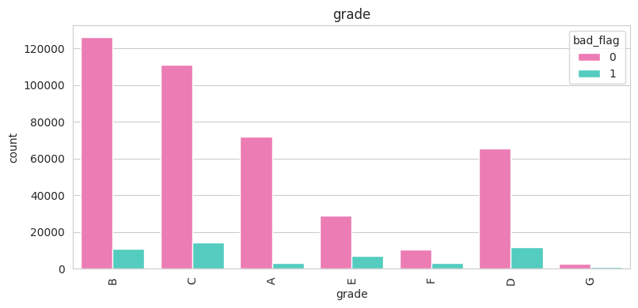

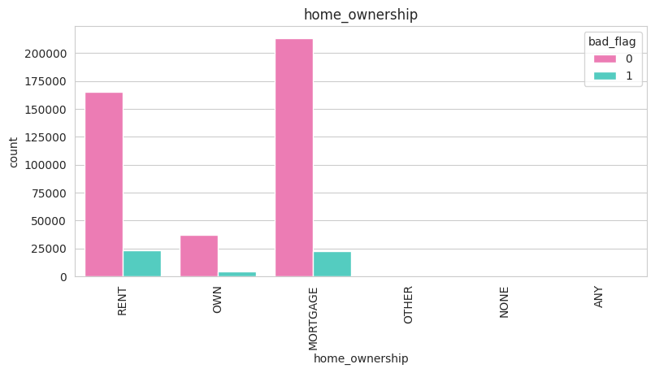

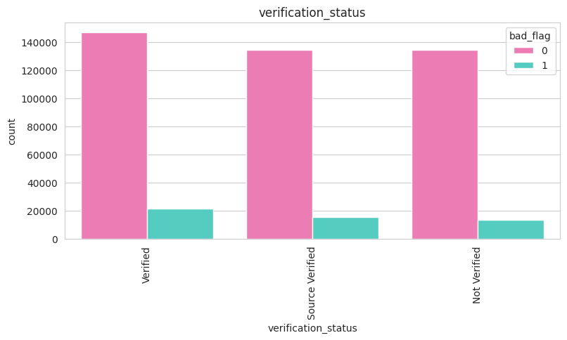

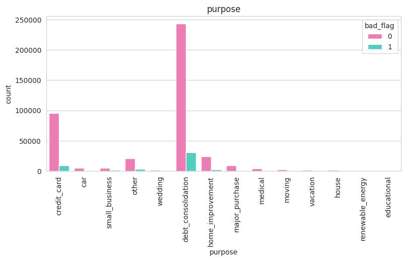

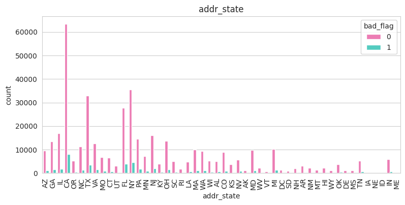

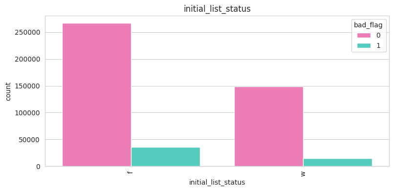

```python
custom_palette = sns.color_palette(["#ff69b4", "#40e0d0"])
plt.style.use("default")
sns.set_style("whitegrid")

# Looping to create countplot visualizations
for column in cat_var:
    plt.figure(figsize=(20, 4))
    plt.subplot(121)
    sns.countplot(x=df[column], hue=df["bad_flag"], palette=custom_palette)
    plt.title(column)
    plt.xticks(rotation=90)
    plt.show()
```

# Check Missing Value

```python
# Calculating the percentage of missing values for each feature
missing_percentage = df.isnull().sum() * 100 / df.shape[0]

# Selecting only features with missing values
missing_values = missing_percentage[missing_percentage > 0].sort_values(ascending=False)

# Displaying the results
print("Percentage of missing values for each feature:")
print(missing_values)
```

```
Percentage of missing values for each feature:
mths_since_last_record         86.566585
mths_since_last_delinq         53.690554
emp_length_int                  4.505399
revol_util                      0.072917
collections_12_mths_ex_med      0.031097
delinq_2yrs                     0.006219
inq_last_6mths                  0.006219
open_acc                        0.006219
pub_rec                         0.006219
total_acc                       0.006219
acc_now_delinq                  0.006219
mths_since_earliest_cr_line     0.006219
annual_inc                      0.000858
dtype: float64
```

```python
df.drop('mths_since_last_record', axis = 1, inplace = True)
```

# Data Imputation

```python
df['annual_inc'].fillna(df['annual_inc'].median(), inplace=True)
df['mths_since_earliest_cr_line'].fillna(0, inplace=True)
df['acc_now_delinq'].fillna(0, inplace=True)
df['total_acc'].fillna(0, inplace=True)
df['pub_rec'].fillna(0, inplace=True)
df['open_acc'].fillna(0, inplace=True)
df['inq_last_6mths'].fillna(0, inplace=True)
df['delinq_2yrs'].fillna(0, inplace=True)
df['collections_12_mths_ex_med'].fillna(0, inplace=True)
df['revol_util'].fillna(0, inplace=True)
df['emp_length_int'].fillna(0, inplace=True)
df['mths_since_last_delinq'].fillna(-1, inplace=True)
```

[output not shown]

[output cut: 29 more lines]

[output not shown]

# Label Encoding

```python
from sklearn.preprocessing import LabelEncoder
label = LabelEncoder()

for column in cat_var:
  df[column] = label.fit_transform(df[column])
```

```python
df.head()
```

|  | loan_amnt | int_rate | grade | home_ownership | annual_inc | verification_status | purpose | addr_state | dti | delinq_2yrs | ... | out_prncp | total_rec_late_fee | recoveries | collections_12_mths_ex_med | acc_now_delinq | bad_flag | term_int | emp_length_int | mths_since_issue_d | mths_since_earliest_cr_line |
| --- | --- | --- | --- | --- | --- | --- | --- | --- | --- | --- | --- | --- | --- | --- | --- | --- | --- | --- | --- | --- | --- |
| 0 | 5000 | 10.65 | 1 | 5 | 24000.0 | 2 | 1 | 3 | 27.65 | 0.0 | ... | 0.0 | 0.00 | 0.00 | 0.0 | 0.0 | 0 | 36.0 | 10.0 | 72 | 395.0 |
| 1 | 2500 | 15.27 | 2 | 5 | 30000.0 | 1 | 0 | 10 | 1.00 | 0.0 | ... | 0.0 | 0.00 | 117.08 | 0.0 | 0.0 | 1 | 60.0 | 1.0 | 72 | 224.0 |
| 2 | 2400 | 15.96 | 2 | 5 | 12252.0 | 0 | 11 | 14 | 8.72 | 0.0 | ... | 0.0 | 0.00 | 0.00 | 0.0 | 0.0 | 0 | 36.0 | 10.0 | 72 | 193.0 |
| 3 | 10000 | 13.49 | 2 | 5 | 49200.0 | 1 | 9 | 4 | 20.00 | 0.0 | ... | 0.0 | 16.97 | 0.00 | 0.0 | 0.0 | 0 | 36.0 | 10.0 | 72 | 262.0 |
| 4 | 3000 | 12.69 | 1 | 5 | 80000.0 | 1 | 9 | 36 | 17.94 | 0.0 | ... | 766.9 | 0.00 | 0.00 | 0.0 | 0.0 | 0 | 60.0 | 1.0 | 72 | 263.0 |

5 rows × 28 columns

# Handling Imbalanced Data

```python
# Handling Imbalance Data
from imblearn.over_sampling import SMOTE

# Misalkan fitur (X) dan Target (y)
X = df.drop('bad_flag', axis = 1)
y = df['bad_flag']

oversampling = SMOTE(random_state = 12, sampling_strategy=1)
```

```python
# Convert all columns to numeric data type
X = X.apply(pd.to_numeric, errors='coerce')

# Fit the over sampling
X,y = oversampling.fit_resample(X, y)
```

```python
y.value_counts()
```

| bad_flag | count |
| --- | --- |
| 0 | 416078 |
| 1 | 416078 |

**dtype:** int64

# Train Test Split

```python
from sklearn.model_selection import train_test_split

# Splitting the data into training and test sets
X_train, X_test, y_train, y_test = train_test_split(X, y, test_size=0.2, random_state=42)

# Displaying the shape of the training and test data
print("Shape of training data:", X_train.shape)
print("Shape of test data:", X_test.shape)
```

```
Shape of training data: (665724, 27)
Shape of test data: (166432, 27)
```

# Standardization

```python
from sklearn.preprocessing import StandardScaler

scaler = StandardScaler()
X_train_scaled = scaler.fit_transform(X_train)
X_test_scaled = scaler.transform(X_test)

X_train_scaled = pd.DataFrame(X_train_scaled, columns=X.columns)
X_test_scaled = pd.DataFrame(X_test_scaled, columns=X.columns)
```

```python
# After standardization
X_train_scaled.head()
```

|  | loan_amnt | int_rate | grade | home_ownership | annual_inc | verification_status | purpose | addr_state | dti | delinq_2yrs | ... | initial_list_status | out_prncp | total_rec_late_fee | recoveries | collections_12_mths_ex_med | acc_now_delinq | term_int | emp_length_int | mths_since_issue_d | mths_since_earliest_cr_line |
| --- | --- | --- | --- | --- | --- | --- | --- | --- | --- | --- | --- | --- | --- | --- | --- | --- | --- | --- | --- | --- | --- |
| 0 | -1.438353 | -1.334251 | -1.541188 | -1.047351 | 0.166413 | -1.217962 | 2.315803 | 0.055933 | -0.998565 | -0.383866 | ... | -0.558263 | -0.54304 | -0.222853 | -0.225538 | -0.090281 | -0.06201 | -0.711590 | -1.056859 | 1.318769 | 0.786168 |
| 1 | -0.317922 | -0.065710 | 0.072721 | 1.180810 | -0.462522 | -1.217962 | -0.717429 | -0.604396 | 0.133196 | -0.383866 | ... | 1.791270 | -0.54304 | -0.222853 | -0.360305 | -0.090281 | -0.06201 | -0.711590 | 0.381718 | -0.913518 | -1.283182 |
| 2 | 0.447599 | -0.104032 | 0.072721 | -1.047351 | 0.081661 | 1.318637 | -0.717429 | -1.117984 | 0.708920 | -0.257331 | ... | -0.558263 | -0.54304 | -0.222853 | 1.251509 | -0.090281 | -0.06201 | -0.711590 | -0.603979 | 0.202625 | 0.614004 |
| 3 | -1.057216 | -0.629389 | -0.734233 | -0.490311 | -0.198775 | 0.050338 | 1.015847 | -0.384286 | -0.424874 | -0.383866 | ... | -0.558263 | -0.54304 | -0.222853 | -0.295730 | -0.090281 | -0.06201 | -0.711590 | -0.503252 | 1.244359 | -0.973541 |
| 4 | 0.280611 | 1.246830 | 0.879676 | -1.047351 | 0.308431 | 0.050338 | -0.284110 | -0.531026 | -0.160613 | 0.961152 | ... | -0.558263 | -0.54304 | -0.222853 | 1.729796 | -0.090281 | -0.06201 | 1.577287 | -0.798242 | -0.392651 | -1.534020 |

5 rows × 27 columns

# Logistic Regression

```python
from sklearn.linear_model import LogisticRegression
logreg = LogisticRegression()
logreg.fit(X_train_scaled, y_train)
```

```
LogisticRegression()
```

```python
y_train_pred = logreg.predict(X_train_scaled)
y_test_pred = logreg.predict(X_test)
```

# Decision Tree

```python
from sklearn.tree import DecisionTreeClassifier

# Initialize Decision Tree model
tree_clf = DecisionTreeClassifier()

# Train the model with scaled training data
tree_clf.fit(X_train_scaled, y_train)

# Predict on training and test data
y_train_pred_tree = tree_clf.predict(X_train_scaled)
y_test_pred_tree = tree_clf.predict(X_test)
```

# **Evaluation**

## Receiver Operating Characteristic (ROC) Curve

The ROC curve (AUC) evaluates a model's ability to distinguish between classes as the decision threshold varies.

- The vertical axis represents the True Positive Rate (TPR) or Sensitivity.
- The horizontal axis represents the False Positive Rate (FPR).

The ROC curve illustrates the balance between TPR and FPR at different classification thresholds. Ideally, the curve should move toward the top-left corner, indicating high TPR and low FPR.

# ROC-AUC for Logistic Regression Training Model

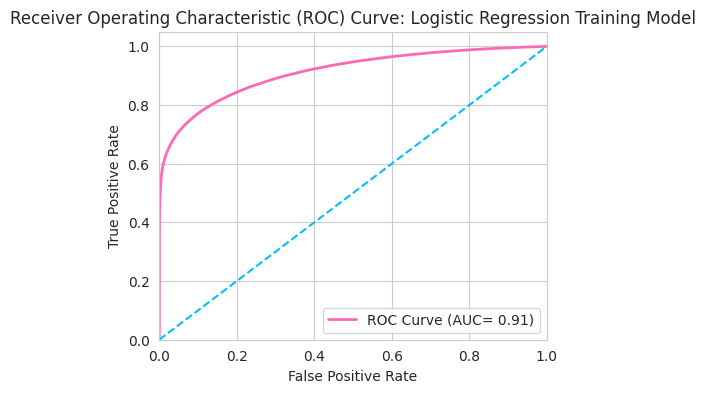

```python
from sklearn.metrics import roc_curve, roc_auc_score
import matplotlib.pyplot as plt

# Predict probabilities for the test set
y_prob = logreg.predict_proba (X_train_scaled) [:, 1]

# Calculate the ROC curve and AUC
fpr, tpr, thresholds = roc_curve(y_train, y_prob)
roc_auc = roc_auc_score (y_train, y_prob)

# Plot the ROC curve
plt.figure(figsize=(5, 4))
plt.plot(fpr, tpr, color='#FF69B4', lw=2, label=f'ROC Curve (AUC= {roc_auc:.2f})')
plt.plot([0, 1], [0, 1], color='DeepSkyBlue', linestyle='--')
plt.xlim([0.0, 1.0])
plt.ylim([0.0, 1.05])
plt.xlabel('False Positive Rate')
plt.ylabel('True Positive Rate')
plt.title('Receiver Operating Characteristic (ROC) Curve: Logistic Regression Training Model')
plt.legend(loc='lower right')
plt.show()
```

# ROC-AUC for Logistic Regression Testing Model

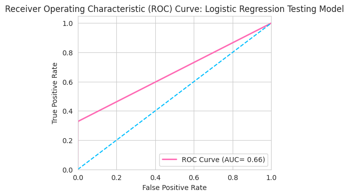

```python
# Predict probabilities for testing data
y_prob_logreg_test = logreg.predict_proba(X_test)[:, 1]

# Calculate ROC curve and AUC for testing data
fpr_logreg_test, tpr_logreg_test, thresholds_logreg_test = roc_curve(y_test, y_prob_logreg_test)
roc_auc_logreg_test = roc_auc_score(y_test, y_prob_logreg_test)

# Plot ROC curve for testing data
plt.figure(figsize=(5, 4))
plt.plot(fpr_logreg_test, tpr_logreg_test, color='#FF69B4', lw=2, label=f'ROC Curve (AUC= {roc_auc_logreg_test:.2f})')
plt.plot([0, 1], [0, 1], color='DeepSkyBlue', linestyle='--')
plt.xlim([0.0, 1.0])
plt.ylim([0.0, 1.05])
plt.xlabel('False Positive Rate')
plt.ylabel('True Positive Rate')
plt.title('Receiver Operating Characteristic (ROC) Curve: Logistic Regression Testing Model')
plt.legend(loc='lower right')
plt.show()
```

# Receiver Operating Characteristic (ROC) Curve for Logistic Regression Model

Overall, the graphs suggest potential overfitting on the training data, as there is a significant drop in AUC when testing on new data. The model performs well on the training data but fails to maintain the same performance on new data. The next step is to reduce overfitting and adjust model parameters to improve AUC on testing data.

# ROC-AUC for Decision Tree Training Model

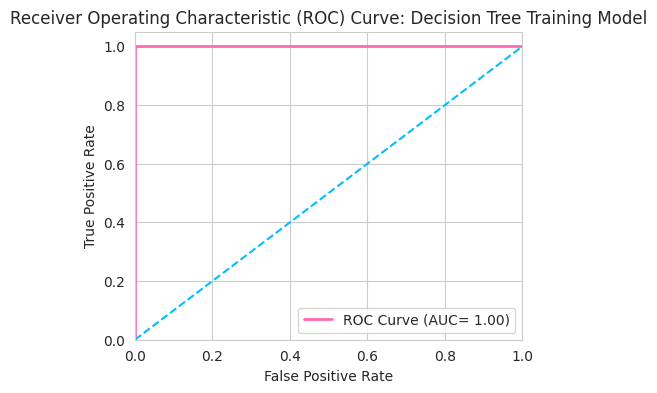

```python
# Predict probabilities for training data
y_prob_tree = tree_clf.predict_proba(X_train_scaled)[:, 1]

# Calculate ROC curve and AUC
fpr_tree, tpr_tree, thresholds_tree = roc_curve(y_train, y_prob_tree)
roc_auc_tree = roc_auc_score(y_train, y_prob_tree)

# Plot ROC curve
plt.figure(figsize=(5, 4))
plt.plot(fpr_tree, tpr_tree, color='#FF69B4', lw=2, label=f'ROC Curve (AUC= {roc_auc_tree:.2f})')
plt.plot([0, 1], [0, 1], color='DeepSkyBlue', linestyle='--')
plt.xlim([0.0, 1.0])
plt.ylim([0.0, 1.05])
plt.xlabel('False Positive Rate')
plt.ylabel('True Positive Rate')
plt.title('Receiver Operating Characteristic (ROC) Curve: Decision Tree Training Model')
plt.legend(loc='lower right')
plt.show()
```

# ROC-AUC for Decision Tree Testing Model

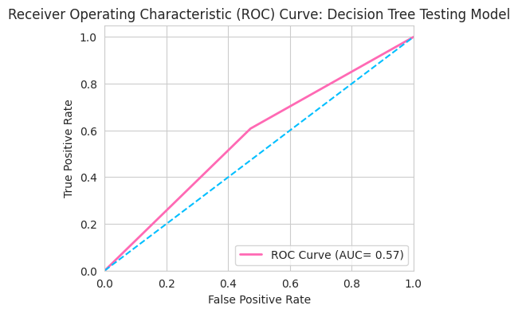

```python
# Predict probabilities for testing data
y_prob_tree_test = tree_clf.predict_proba(X_test)[:, 1]

# Calculate ROC curve and AUC for testing data
fpr_tree_test, tpr_tree_test, thresholds_tree_test = roc_curve(y_test, y_prob_tree_test)
roc_auc_tree_test = roc_auc_score(y_test, y_prob_tree_test)

# Plot ROC curve for testing data
plt.figure(figsize=(5, 4))
plt.plot(fpr_tree_test, tpr_tree_test, color='#FF69B4', lw=2, label=f'ROC Curve (AUC= {roc_auc_tree_test:.2f})')
plt.plot([0, 1], [0, 1], color='DeepSkyBlue', linestyle='--')
plt.xlim([0.0, 1.0])
plt.ylim([0.0, 1.05])
plt.xlabel('False Positive Rate')
plt.ylabel('True Positive Rate')
plt.title('Receiver Operating Characteristic (ROC) Curve: Decision Tree Testing Model')
plt.legend(loc='lower right')
plt.show()
```

# Receiver Operating Characteristic (ROC) Curve for Decision Tree Model

1. **ROC Curve for Training Data**
   - The AUC is 1.00, indicating perfect performance on the training data.
   - A high AUC shows the model can distinguish well between positive and negative classes on the training data.
2. **ROC Curve for Testing Data**
   - The AUC is 0.57, indicating that the model performs much worse on the testing data compared to the training data.
   - An AUC close to 0.5 suggests the model's ability to differentiate between classes is almost equivalent to random guessing.

The significant difference between AUC on training and testing data suggests overfitting. This occurs when the model is too complex and fits the training data too closely, failing to generalize well to unseen data.

# **Conclusion**

**Conclusion**  
The evaluation of both the Logistic Regression and Decision Tree models highlights important insights regarding model performance and generalization.

- For **Logistic Regression**, the model performs excellently on the training data (AUC = 0.91), but struggles to generalize to new, unseen data (AUC = 0.66), suggesting potential overfitting. This indicates that while the model fits the training data well, it fails to maintain the same level of accuracy on testing data. Further adjustments, such as regularization or parameter tuning, are necessary to improve its performance on unseen data.
- For the **Decision Tree**, the model shows perfect performance on training data (AUC = 1.00), but its performance on the testing data is significantly worse (AUC = 0.57), indicating strong overfitting. This suggests that the decision tree has become overly complex and has learned the noise in the training data rather than the underlying patterns. Simplifying the model, using pruning techniques, or applying cross-validation could help reduce overfitting and improve generalization.

Overall, both models show signs of overfitting, and further steps are needed to enhance their ability to generalize to new data, ensuring more reliable predictions in real-world scenarios.